# inferential_assignment_1_part2

treepruner

September 24, 2015

## Description

This part of the exercise analyzes the effect of citamin C on tooth growth in guinea pigs. The ToothGrowth data in the R datasets package.

The response is the length of odontoblasts (teeth) in each of 10 guinea pigs at each of three dose levels of Vitamin C (0.5, 1, and 2 mg) with each of two delivery methods (orange juice or ascorbic acid).

## Assumptions

I assumed that the guinea pigs were randomly assigned to the treatment groups and each guinea pig only received on type of supplement, e.g., they were NOT paired observations.

## Exploratory Data Analyses

Determine the variables, class and sample values.

```
## 'data.frame':    60 obs. of  3 variables:
##  $ len : num  4.2 11.5 7.3 5.8 6.4 10 11.2 11.2 5.2 7 ...
##  $ supp: Factor w/ 2 levels "OJ","VC": 2 2 2 2 2 2 2 2 2 2 ...
##  $ dose: num  0.5 0.5 0.5 0.5 0.5 0.5 0.5 0.5 0.5 0.5 ...
```

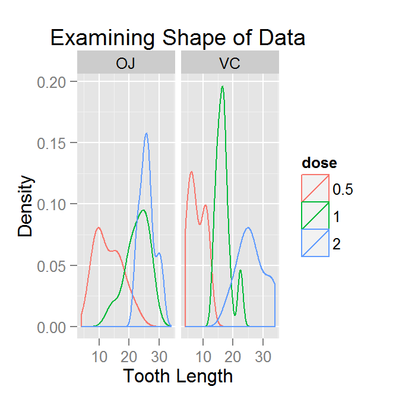

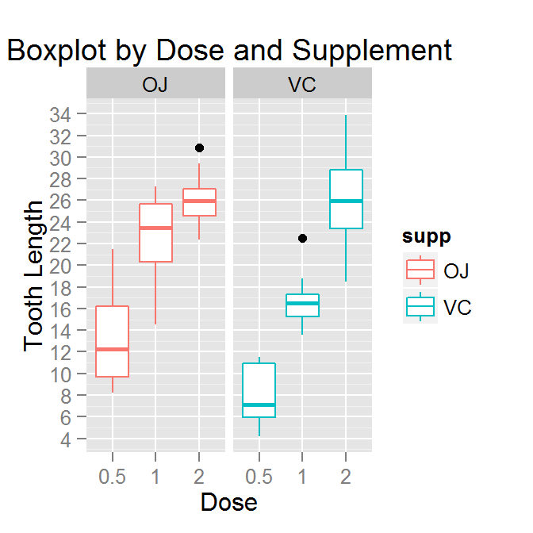

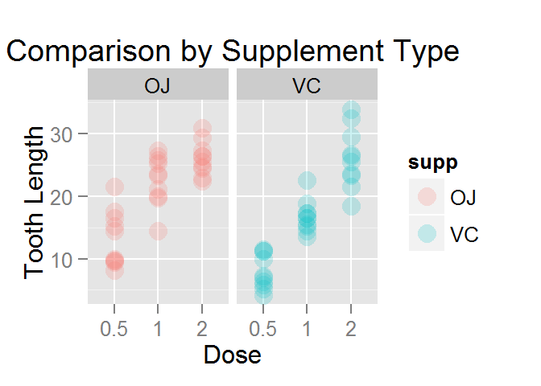

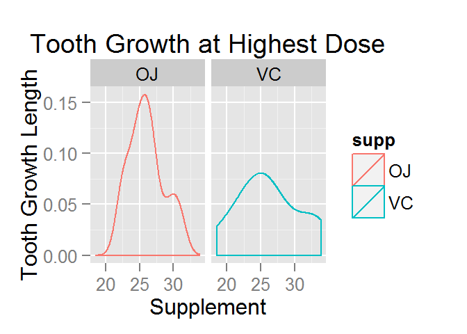

## Data Summary

```
## Source: local data frame [6 x 9]
## Groups: supp
##
##   supp dose n() mean(len) median(len) IQR(len)  sd(len) min(len) max(len)
## 1   OJ  0.5  10     13.23       12.25    6.475 4.459709      8.2     21.5
## 2   OJ    1  10     22.70       23.45    5.350 3.910953     14.5     27.3
## 3   OJ    2  10     26.06       25.95    2.500 2.655058     22.4     30.9
## 4   VC  0.5  10      7.98        7.15    4.950 2.746634      4.2     11.5
## 5   VC    1  10     16.77       16.50    2.025 2.515309     13.6     22.5
## 6   VC    2  10     26.14       25.95    5.425 4.797731     18.5     33.9
```

## Use Confidence Intervals and/or Hypothesis on ToothGrowth

### Test 1

The highest dose of each supplement has the highest growth. At this level the mean and the median are approximately the same for each supplement, but VC has a wider spread than OJ. Is this difference significant? Perform a T Test on the dose2 subset.

```
##
##  Welch Two Sample t-test
##
## data:  len by supp
## t = -0.0461, df = 14.04, p-value = 0.9639
## alternative hypothesis: true difference in means is not equal to 0
## 95 percent confidence interval:
##  -3.79807  3.63807
## sample estimates:
## mean in group OJ mean in group VC
##            26.06            26.14
```

The 95% confidence interval for Test 1 contains 0, so we can not reject the NULL hypothesis that there is no different between the means of the groups.

### Test 2

There is an overlap in the boxplots for OJ at doses 1 and 2. Is this difference significant?

```
##
##  Welch Two Sample t-test
##
## data:  len by dose
## t = -2.2478, df = 15.842, p-value = 0.0392
## alternative hypothesis: true difference in means is not equal to 0
## 95 percent confidence interval:
##  -6.5314425 -0.1885575
## sample estimates:
## mean in group 1 mean in group 2
##           22.70           26.06
```

The 95% confidence interval for Test 2 does not contain 0 and the p value is less than .05, so these results are significantly different from each other.

### Test 3

There is an overlap in the boxplots dose .5. Is this difference significant?

```
##
##  Welch Two Sample t-test
##
## data:  len by supp
## t = 3.1697, df = 14.969, p-value = 0.006359
## alternative hypothesis: true difference in means is not equal to 0
## 95 percent confidence interval:
##  1.719057 8.780943
## sample estimates:
## mean in group OJ mean in group VC
##            13.23             7.98
```

The 95% confidence interval for Test 3 does not contain 0 ad the p value is less than .05, so these resuls are significantly different from each other.

## Conclusions

There sample sizes were very small, only 10 observations per supplement and dose combinations. The T-test is valid for small sample sizes.

If you want to maximize guinea pig tooth growth either orange juice or Vitamin C at dose = 2mg are effective and there isn’t a significant difference in their performance. Choose the supplement based upon price or availability.

If you want to minimize guinea pig tooth growth, Vitamin C at the 0.5 mg dose is significantly lower than orange juice at 0.5 mg.